# Lab_05R

36-290 – Statistical Research Methodology

Week 5 Thursday – Fall 2021

# Preliminaries

## Goal

Today you will create a logistic regression model for classifying stars vs. quasars and you will assess your performance by computing a test-set misclassification rate.

## Data

We’ll begin by importing data on stars and quasars:

```r
file.path = "https://raw.githubusercontent.com/pefreeman/36-290/master/EXAMPLE_DATASETS/STAR_QUASAR/Star_Quasar.Rdata"
load(url(file.path))
rm(file.path)
```

The data frame `df` has 8 measurements each for 500 quasars (faraway active galactic nuclei that look like stars) and for 500 stars. The first five columns are u-, g-, r-, i-, and z-band magnitudes, the sixth column is redshift (high for quasars, approximately zero for stars), the seventh column is redshift error, and the eighth column is a factor variable that denotes the class (`QSO` or `STAR`).

The goal is to see if you can correctly classify each object. We will set up a predictor data frame with four colors and a magnitude, and a response vector that is a factor variable with two levels (“QSO” and “STAR”). (Including redshift as a predictor would be cheating: the redshift is how we know for sure whether the objects are quasars or stars in the first place!)

```r
col.ug = df$u.mag - df$g.mag
col.gr = df$g.mag - df$r.mag
col.ri = df$r.mag - df$i.mag
col.iz = df$i.mag - df$z.mag
mag.r  = df$r.mag
predictors = data.frame(col.ug,col.gr,col.ri,col.iz,mag.r)
response   = df$class
```

# Questions

## Question 1

Split the data into training and test sets. Then use `ggpairs()` to display the (full) predictor space, while using the argument `mapping=aes(color=response)` to use separate colors for quasars and for stars. Based on what you see, do you expect a clean separation between quasars and stars? (In other words, do you expect a low misclassification rate?)

```r
library(GGally)
```

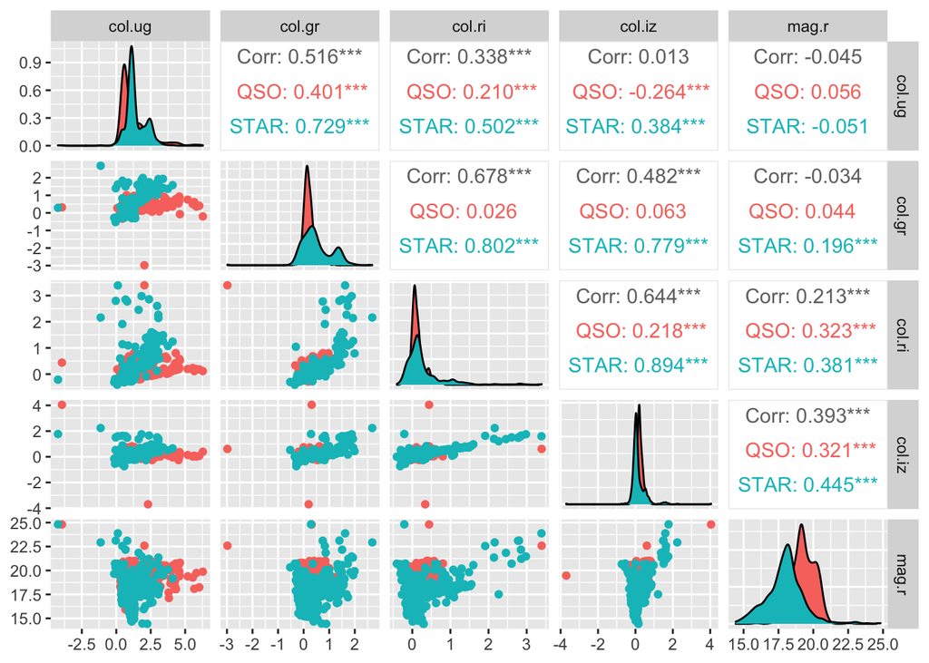

```
I don't expect too clear of a separation because there does seem to be a bit of overlap to some extent.
```

```r
library(ggplot2)

set.seed(100)
fraction=.7
sp = sample(nrow(predictors), round(fraction*nrow(predictors)))
pred.train = predictors[sp ,]
pred.test = predictors[-sp ,]

respdf = data.frame(response)
set.seed(100)
fraction=.7
sr = sample(length(response), round(fraction*length(response)))
resp.train = respdf[sr ,]
resp.test = respdf[-sr ,]



ggpairs(predictors,progress=FALSE, mapping=aes(color=response))
```